# Project 1

Navruzbek Karamatov

March 11, 2019

## Stock returns

Initially, important libraries are called.

```r
library(lubridate)
library(dplyr)
```

First, raw data is imported and all columns are made numeric.

```r
mydata=read.csv("C:/Users/navruzbek/Desktop/r_projects/stock return data analysis/returns_20181228.csv",
                sep=",", dec=".", stringsAsFactors=FALSE, header=TRUE)
mydata2 = apply(mydata[,2:ncol(mydata)], 2, as.numeric)
```

To analyze if stock has momentum or mean reversion Autoregressive (AR) model of order 1 is fitted. Thus, only AR(1) is fitted for each stocks and for each month separately.

Data with zeros are labeled “NA” to drop out later.

```r
mydata2 = cbind(mydata[,1], mydata2)
mydata2[ mydata2 == 0 ] = NA
```

Now, month and year information is obtained to roll over them. Also, “merged_data” is created to merge the result to it.

```r
mydate = mdy(mydata2[,1])
mymonth=month(mydate) #get the month
myyear=year(mydate) #get the year
mydata2 = cbind(myyear, mymonth, mydata2)
merged_data = c(rep(1990, 12),rep(1991, 12),rep(1992, 12),rep(1993, 12))
merged_data = cbind(merged_data, (rep(seq(1,12,1),4)))
colnames(merged_data) = c('years','months')
```

First, simply cross sectional stock returns are checked for some random date.

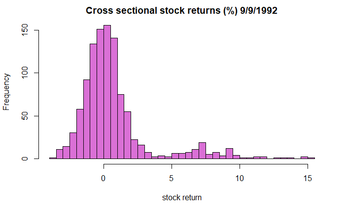

```r
i = 700
temp_var = na.omit(as.numeric(as.character(mydata2[i,4:ncol(mydata2)])))
temp_info = mydata2[i,3]
hist(temp_var, breaks = 50, xlab='stock return', ylab = 'Frequency', col ='#DA70D6',
     main = paste('Cross sectional stock returns (%)', temp_info))
```

Clearly, returns are not normally and asymmetrically distributed. Thus, returns have abnormal behavior.

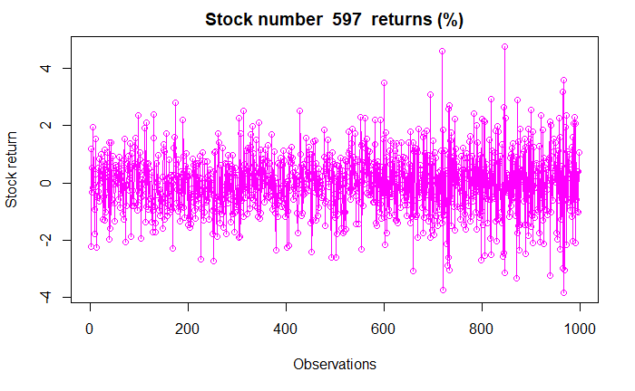

```r
i = 600
temp_var = na.omit(as.numeric(as.character(mydata2[,i])))
plot(temp_var, ylab='Stock return', xlab = 'Observations', col ='#FF00FF',
     main = paste('Stock number ', i - 3, ' returns (%)'), type='o')
```

Time series plot also reveals some unusual behavior. Stock returns are experiencing higher volatility in recent observations.

Now, AR(1) is fitted to each stock and for every month by looping through them. Data is merged to “merged_data” based on month and year information.

```r
for (j in 4:ncol(mydata2)){
  expdata = mydata2[,c(1,2,j)]
  expdata = na.omit(expdata)
  expdata1 = list()
  expdata1 = as.data.frame(expdata1)

  mymonths = unique(expdata[,2])
  myyears = unique(expdata[,1])

  for(m in 1:length(myyears)){
    AA = as.numeric(myyears[m])
    for(i in 1:length(mymonths)){
      BB = as.numeric(mymonths[i])
      if(AA == 1993 & BB == 11){break}
      newdata <- as.data.frame(expdata[ which( expdata[,1] == AA & expdata[,2] == BB), ])
      if ( nrow(newdata) < 15){break}
      fitted = arima(as.numeric(as.character(newdata[,3])), order = c(1,0,0),method="ML")
      mycoef = as.data.frame(t(c(AA,BB,fitted$coef[1])))
      expdata1 = bind_rows(expdata1, mycoef)
    }
  }
  colnames(expdata1) = c('years', 'months', paste('stock', j-3))
  merged_data = merge(merged_data, expdata1, by=c('years', 'months'), all.x=TRUE)
}
```

After obtaining AR(1) model coefficient for each stock and for each month, the average of coefficient across stocks is obtained by rowmeans.

```r
mean_data_ar = rowMeans(merged_data[,3:ncol(merged_data)], na.rm=TRUE)
mean_data_ar = cbind(merged_data[,1:2], mean_data_ar)
```

From plot it is clear that stocks’ average AR coefficient behaved differently before and after 28th month which is 4-1992 in our data.

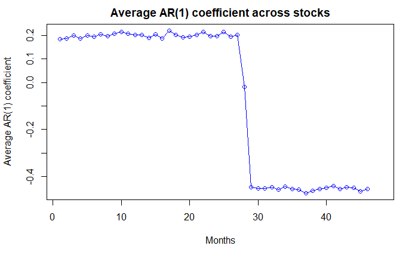

```r
plot(mean_data_ar[,3], type='o', col='blue', ylab='Average AR(1) coefficient',
     xlab='Months', main = "Average AR(1) coefficient across stocks")
```

So, before 4-1992 stocks had momentum behavior and AR coefficient is positve. However, after 4-1992 stocks started experiencing mean reversion as it can be seen from a negative AR coefficient.

```r
merged_data[28,1]
```

```
[1] 1992
```

```r
merged_data[28,2]
```

```
[1] 4
```

Now the average AR(1) coefficient across months and stocks obtained before and after 4-1992.

```r
before_28 = mean(mean_data_ar[1:27,3])
before_28
```

```
[1] 0.1995989
```

Thus, before 4-1992 stocks on average experienced the momentum as can be seen from a positive AR coefficient. Previous day’s return and today’s return moved in the same directions.

```r
after_28 = mean(mean_data_ar[29:46,3])
after_28
```

```
[1] -0.4516244
```

However, following 4-1992 stocks started experiencing the mean-reversion. Lag coefficient is large and negative meaning that when previous day’s return went down (up) today’s return moved up (down).